# Assignment_3

2023-03-20

1. (2 pt) Load adult.data into a dataframe in R. Note that adult.data does not have column names in the first line so you need to set header=FALSE when you read the data then manually set the column names. Inspect the dataset using “str” and “summary” functions. What is the type of each variable in the dataset numeric/continuous or categorical/discrete? For each categorical variable explain whether it is nominal or ordinal.

```r
adult_data =  read.csv("C:/New folder/adult.data.csv", header=FALSE, strip.white=TRUE,na = c("NA", "?"))
```

```r
str(adult_data)
```

```
## 'data.frame':    32561 obs. of  15 variables:
##  $ V1 : int  39 50 38 53 28 37 49 52 31 42 ...
##  $ V2 : chr  "State-gov" "Self-emp-not-inc" "Private" "Private" ...
##  $ V3 : int  77516 83311 215646 234721 338409 284582 160187 209642 45781 159449 ...
##  $ V4 : chr  "Bachelors" "Bachelors" "HS-grad" "11th" ...
##  $ V5 : int  13 13 9 7 13 14 5 9 14 13 ...
##  $ V6 : chr  "Never-married" "Married-civ-spouse" "Divorced" "Married-civ-spouse" ...
##  $ V7 : chr  "Adm-clerical" "Exec-managerial" "Handlers-cleaners" "Handlers-cleaners" ...
##  $ V8 : chr  "Not-in-family" "Husband" "Not-in-family" "Husband" ...
##  $ V9 : chr  "White" "White" "White" "Black" ...
##  $ V10: chr  "Male" "Male" "Male" "Male" ...
##  $ V11: int  2174 0 0 0 0 0 0 0 14084 5178 ...
##  $ V12: int  0 0 0 0 0 0 0 0 0 0 ...
##  $ V13: int  40 13 40 40 40 40 16 45 50 40 ...
##  $ V14: chr  "United-States" "United-States" "United-States" "United-States" ...
##  $ V15: chr  "<=50K" "<=50K" "<=50K" "<=50K" ...
```

```r
summary(adult_data)
```

```
##        V1             V2                  V3               V4
##  Min.   :17.00   Length:32561       Min.   :  12285   Length:32561
##  1st Qu.:28.00   Class :character   1st Qu.: 117827   Class :character
##  Median :37.00   Mode  :character   Median : 178356   Mode  :character
##  Mean   :38.58                      Mean   : 189778
##  3rd Qu.:48.00                      3rd Qu.: 237051
##  Max.   :90.00                      Max.   :1484705
##        V5             V6                 V7                 V8
##  Min.   : 1.00   Length:32561       Length:32561       Length:32561
##  1st Qu.: 9.00   Class :character   Class :character   Class :character
##  Median :10.00   Mode  :character   Mode  :character   Mode  :character
##  Mean   :10.08
##  3rd Qu.:12.00
##  Max.   :16.00
##       V9                V10                 V11             V12
##  Length:32561       Length:32561       Min.   :    0   Min.   :   0.0
##  Class :character   Class :character   1st Qu.:    0   1st Qu.:   0.0
##  Mode  :character   Mode  :character   Median :    0   Median :   0.0
##                                        Mean   : 1078   Mean   :  87.3
##                                        3rd Qu.:    0   3rd Qu.:   0.0
##                                        Max.   :99999   Max.   :4356.0
##       V13            V14                V15
##  Min.   : 1.00   Length:32561       Length:32561
##  1st Qu.:40.00   Class :character   Class :character
##  Median :40.00   Mode  :character   Mode  :character
##  Mean   :40.44
##  3rd Qu.:45.00
##  Max.   :99.00
```

```r
colnames(adult_data) <- c("age", "work_class", "fnlwgt", "education", "education_num", "marital_status", "occupation", "relationship", "race", "sex", "capital_gain", "capital_loss", "hours_per_week", "native_country", "income")
```

```r
str(adult_data)
```

```
## 'data.frame':    32561 obs. of  15 variables:
##  $ age           : int  39 50 38 53 28 37 49 52 31 42 ...
##  $ work_class    : chr  "State-gov" "Self-emp-not-inc" "Private" "Private" ...
##  $ fnlwgt        : int  77516 83311 215646 234721 338409 284582 160187 209642 45781 159449 ...
##  $ education     : chr  "Bachelors" "Bachelors" "HS-grad" "11th" ...
##  $ education_num : int  13 13 9 7 13 14 5 9 14 13 ...
##  $ marital_status: chr  "Never-married" "Married-civ-spouse" "Divorced" "Married-civ-spouse" ...
##  $ occupation    : chr  "Adm-clerical" "Exec-managerial" "Handlers-cleaners" "Handlers-cleaners" ...
##  $ relationship  : chr  "Not-in-family" "Husband" "Not-in-family" "Husband" ...
##  $ race          : chr  "White" "White" "White" "Black" ...
##  $ sex           : chr  "Male" "Male" "Male" "Male" ...
##  $ capital_gain  : int  2174 0 0 0 0 0 0 0 14084 5178 ...
##  $ capital_loss  : int  0 0 0 0 0 0 0 0 0 0 ...
##  $ hours_per_week: int  40 13 40 40 40 40 16 45 50 40 ...
##  $ native_country: chr  "United-States" "United-States" "United-States" "United-States" ...
##  $ income        : chr  "<=50K" "<=50K" "<=50K" "<=50K" ...
```

```r
summary(adult_data)
```

```
##       age         work_class            fnlwgt         education
##  Min.   :17.00   Length:32561       Min.   :  12285   Length:32561
##  1st Qu.:28.00   Class :character   1st Qu.: 117827   Class :character
##  Median :37.00   Mode  :character   Median : 178356   Mode  :character
##  Mean   :38.58                      Mean   : 189778
##  3rd Qu.:48.00                      3rd Qu.: 237051
##  Max.   :90.00                      Max.   :1484705
##  education_num   marital_status      occupation        relationship
##  Min.   : 1.00   Length:32561       Length:32561       Length:32561
##  1st Qu.: 9.00   Class :character   Class :character   Class :character
##  Median :10.00   Mode  :character   Mode  :character   Mode  :character
##  Mean   :10.08
##  3rd Qu.:12.00
##  Max.   :16.00
##      race               sex             capital_gain    capital_loss
##  Length:32561       Length:32561       Min.   :    0   Min.   :   0.0
##  Class :character   Class :character   1st Qu.:    0   1st Qu.:   0.0
##  Mode  :character   Mode  :character   Median :    0   Median :   0.0
##                                        Mean   : 1078   Mean   :  87.3
##                                        3rd Qu.:    0   3rd Qu.:   0.0
##                                        Max.   :99999   Max.   :4356.0
##  hours_per_week  native_country        income
##  Min.   : 1.00   Length:32561       Length:32561
##  1st Qu.:40.00   Class :character   Class :character
##  Median :40.00   Mode  :character   Mode  :character
##  Mean   :40.44
##  3rd Qu.:45.00
##  Max.   :99.00
```

*we can see that the dataset contains 15 variables, out of which 9 are categorical and 6 are numerical. The variable income is the target variable that we want to predic*

*The categorical variables are work_class, education, marital_status, occupation, relationship, race, sex, native_country, and income. Among these, work_class, education, marital_status, occupation, relationship, and race are nominal categorical variables, meaning that there is no inherent order among their categories*

*The numerical variables are age, fnlwgt, education_num, capital_gain, capital_loss, and hours_per_week. The age and hours_per_week variables are continuous numerical variables, as they can take on any value in a given range*

2. (0.5 pt) There are some missing values in this dataset represented as “ ?” (Note: there is a space before ?) . Make sure that all “ ?” are converted to NAs. You can do so by setting “na.strings” parameters in “read.csv” to “ ?”.

*We did that na.strings in the first step while reading the data*

3. (1pt) Set the random seed, and split the data to train/test. Use 80% of samples for training and the remaining 20% for testing. You can use “sample” (similar to what we did in slide 37 of week 6 lecture but you need to adjust1000 and 900 to the number of observations in your dataset and the size of the sample) or alternatively, you can use “createDataPartition” method from caret package.

```r
set.seed(123)
train_index = sample(nrow(adult_data), round(0.8 * nrow(adult_data)), replace = FALSE)

train_data = adult_data[train_index, ]
test_data = adult_data[-train_index, ]
```

4. (2pt) Find which columns in the train and test set have missing values. Replace the missing values in both train and test data with the mean ( if the variable is numeric) or mode (if the variable is categorical). The mode (or mean) we use for imputation should be computed based on the training data only. This is because we don’t want any information from the test data to leak into the model during training. Therefore, instead of imputing based on the mode ( or mean) of entire data, we impute based on the mode (or mean) of the training data.

```r
train_missing = sapply(train_data, function(x) sum(is.na(x)))
test_missing = sapply(test_data, function(x) sum(is.na(x)))

train_missing
```

```
##            age     work_class         fnlwgt      education  education_num
##              0           1468              0              0              0
## marital_status     occupation   relationship           race            sex
##              0           1472              0              0              0
##   capital_gain   capital_loss hours_per_week native_country         income
##              0              0              0            463              0
```

```r
test_missing
```

```
##            age     work_class         fnlwgt      education  education_num
##              0            368              0              0              0
## marital_status     occupation   relationship           race            sex
##              0            371              0              0              0
##   capital_gain   capital_loss hours_per_week native_country         income
##              0              0              0            120              0
```

```r
# train data
for (i in 1:ncol(train_data)) {
  if (train_missing[i] > 0) {
    if (is.numeric(train_data[[i]])) {
      train_mean <- mean(train_data[[i]], na.rm = TRUE)
      train_data[[i]][is.na(train_data[[i]])] <- train_mean
    } else {
      train_mode <- names(which.max(table(train_data[[i]])))
      train_data[[i]][is.na(train_data[[i]])] <- train_mode
    }
  }
}
```

```r
#train data

for (i in 1:ncol(test_data)) {
  if (test_missing[i] > 0) {
    if (is.numeric(test_data[[i]])) {
      test_mean <- mean(train_data[[i]], na.rm = TRUE)
      test_data[[i]][is.na(test_data[[i]])] <- test_mean
    } else {
      test_mode <- names(which.max(table(train_data[[i]])))
      test_data[[i]][is.na(test_data[[i]])] <- test_mode
    }
  }
}
```

```r
sum(is.na(train_data))
```

```
## [1] 0
```

```r
sum(is.na(test_data))
```

```
## [1] 0
```

*Now there is no missing values*

5. (3pt) Use appropriate plots and statistic tests to find which variables in the dataset are associated with “income”. Remove the variable(s) that are not associated with income

```r
#install.packages("ggplot2")
library(ggplot2)
```

```r
names(train_data)
```

```
##  [1] "age"            "work_class"     "fnlwgt"         "education"
##  [5] "education_num"  "marital_status" "occupation"     "relationship"
##  [9] "race"           "sex"            "capital_gain"   "capital_loss"
## [13] "hours_per_week" "native_country" "income"
```

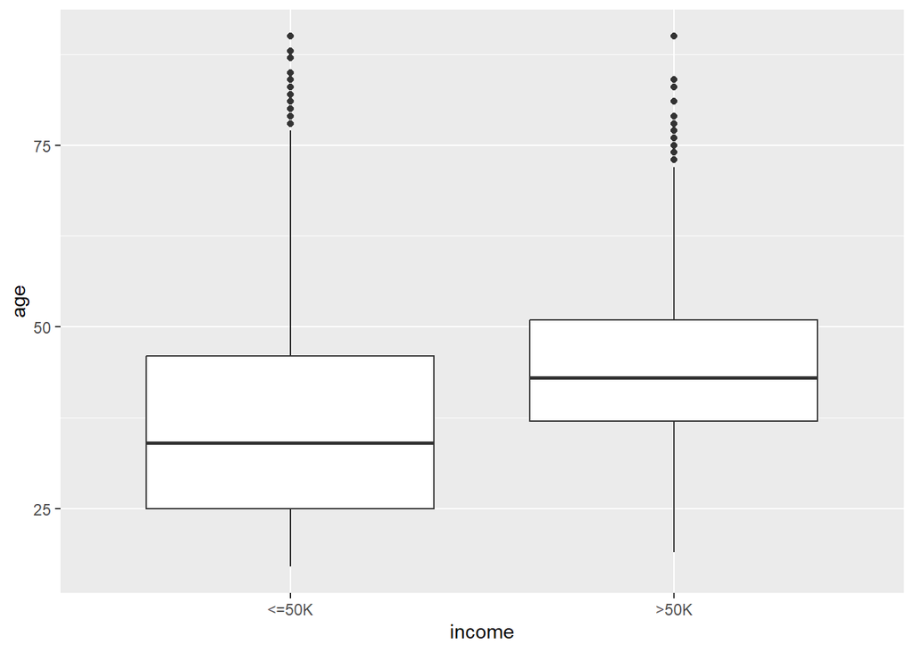

```r
ggplot(train_data, aes(x = income, y = age)) + geom_boxplot()
```

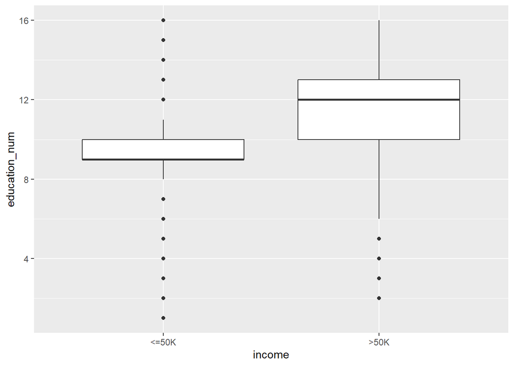

```r
ggplot(train_data, aes(x = income, y = education_num)) + geom_boxplot()
```

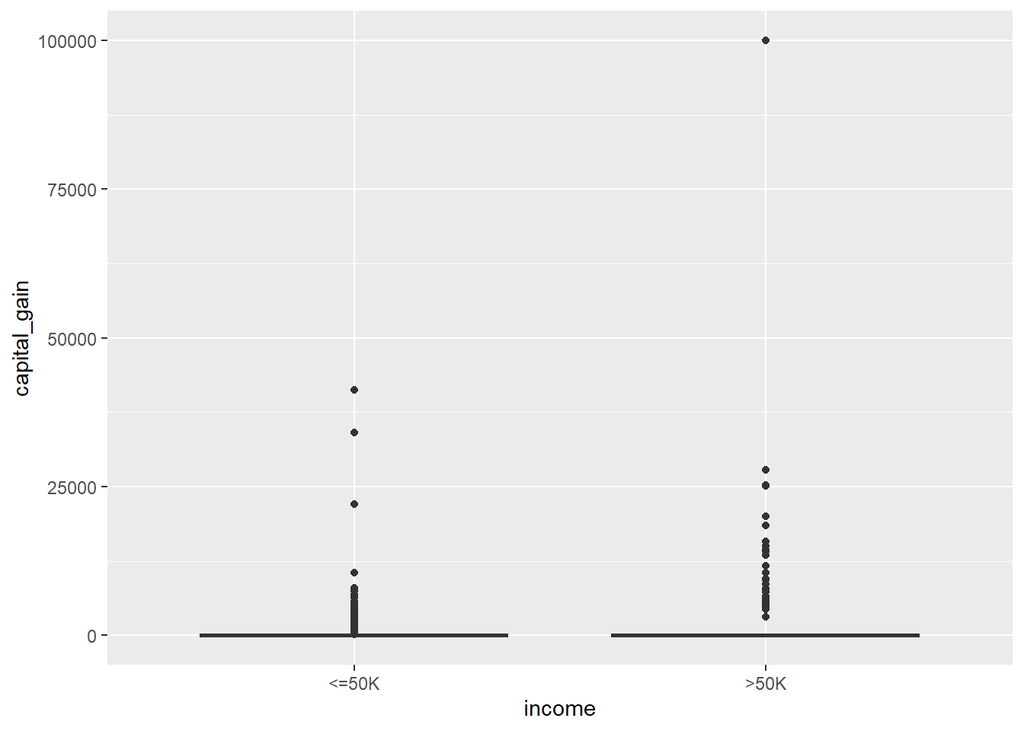

```r
ggplot(train_data, aes(x = income, y = capital_gain)) + geom_boxplot()
```

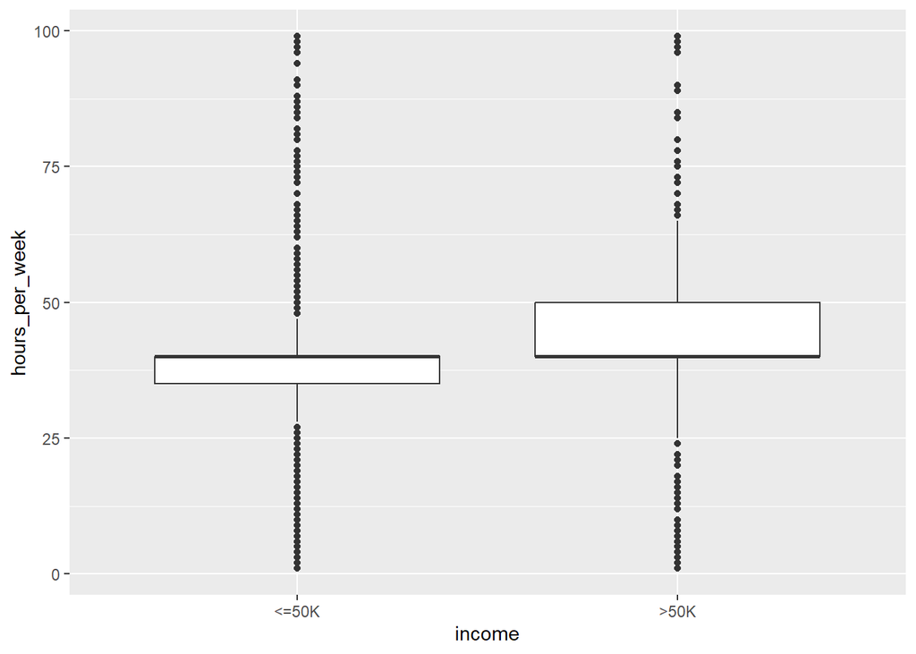

```r
ggplot(train_data, aes(x = income, y = hours_per_week)) + geom_boxplot()
```

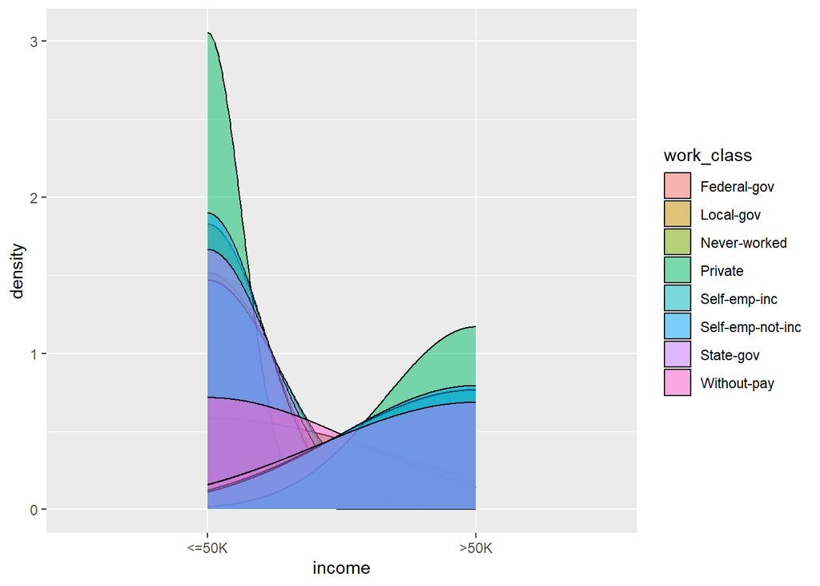

```r
ggplot(train_data, aes(x = income, fill = work_class)) + geom_density(alpha = 0.5)
```

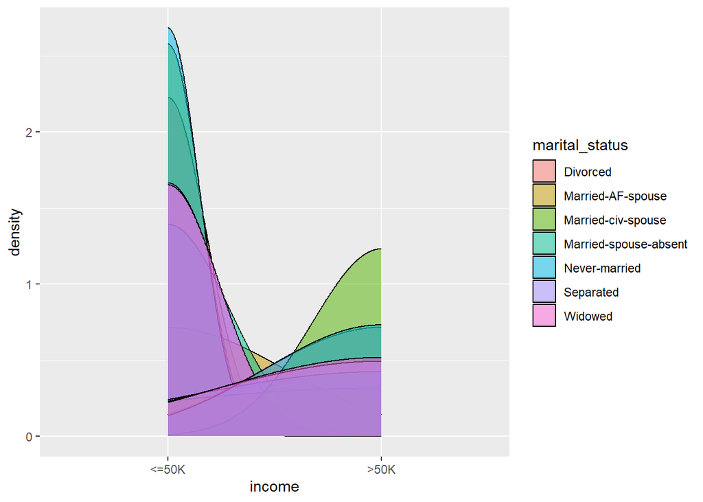

```r
ggplot(train_data, aes(x = income, fill = marital_status)) + geom_density(alpha = 0.5)
```

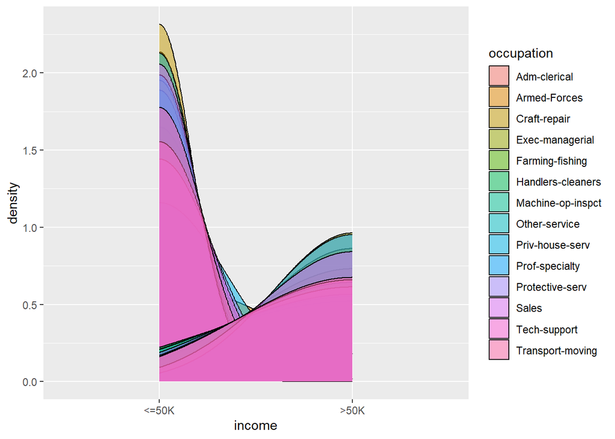

```r
ggplot(train_data, aes(x = income, fill = occupation)) + geom_density(alpha = 0.5)
```

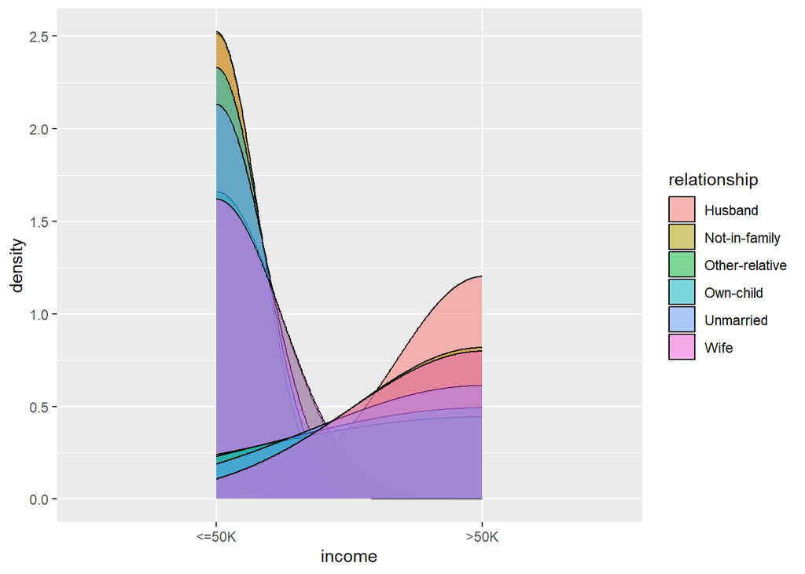

```r
ggplot(train_data, aes(x = income, fill = relationship)) + geom_density(alpha = 0.5)
```

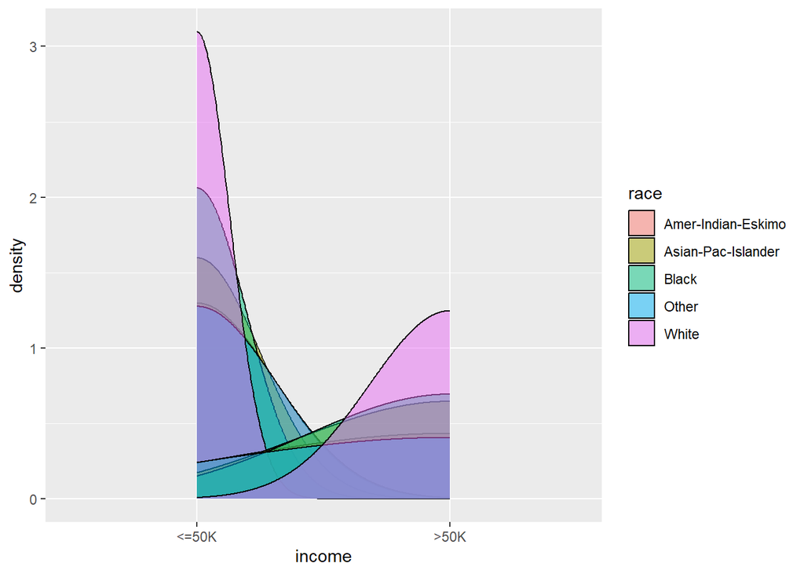

```r
ggplot(train_data, aes(x = income, fill = race)) + geom_density(alpha = 0.5)
```

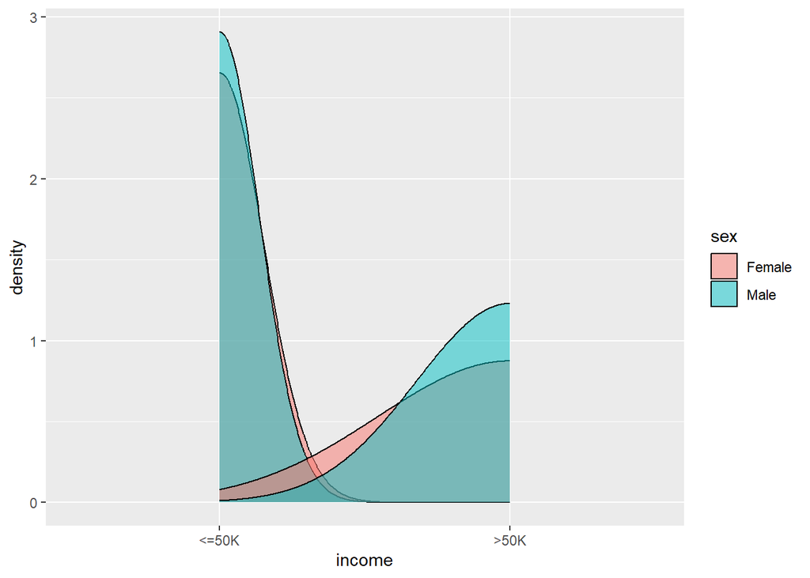

```r
ggplot(train_data, aes(x = income, fill = sex)) + geom_density(alpha = 0.5)
```

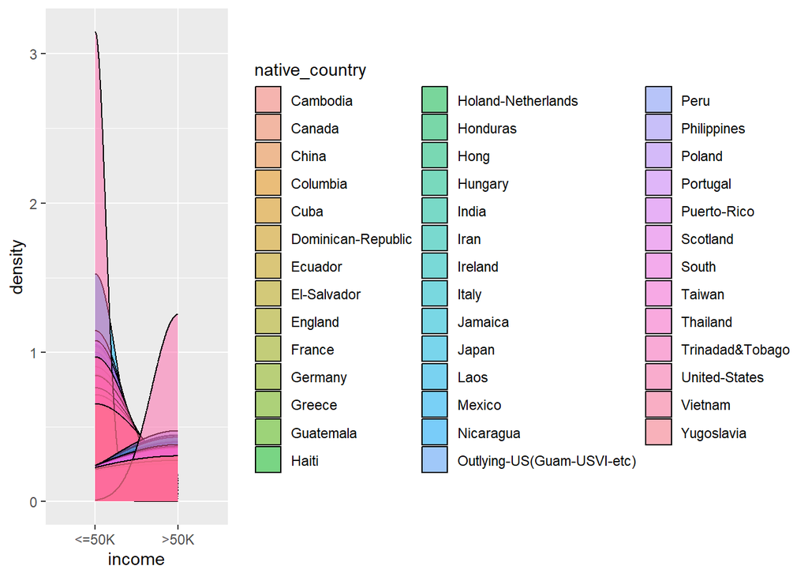

```r
ggplot(train_data, aes(x = income, fill = native_country)) + geom_density(alpha = 0.5)
```

```r
#install.packages("MASS")
library(MASS)
```

```r
# Chi-squared test for categorical variables
chisq.test(table(train_data$income, train_data$work_class))
```

```
##
##  Pearson's Chi-squared test
##
## data:  table(train_data$income, train_data$work_class)
## X-squared = 719.24, df = 7, p-value < 2.2e-16
```

```r
chisq.test(table(train_data$income, train_data$marital_status))
```

```
##
##  Pearson's Chi-squared test
##
## data:  table(train_data$income, train_data$marital_status)
## X-squared = 5162.9, df = 6, p-value < 2.2e-16
```

```r
chisq.test(table(train_data$income, train_data$occupation))
```

```
##
##  Pearson's Chi-squared test
##
## data:  table(train_data$income, train_data$occupation)
## X-squared = 3125.7, df = 13, p-value < 2.2e-16
```

```r
chisq.test(table(train_data$income, train_data$relationship))
```

```
##
##  Pearson's Chi-squared test
##
## data:  table(train_data$income, train_data$relationship)
## X-squared = 5316.4, df = 5, p-value < 2.2e-16
```

```r
chisq.test(table(train_data$income, train_data$race))
```

```
##
##  Pearson's Chi-squared test
##
## data:  table(train_data$income, train_data$race)
## X-squared = 257.67, df = 4, p-value < 2.2e-16
```

```r
chisq.test(table(train_data$income, train_data$sex))
```

```
##
##  Pearson's Chi-squared test with Yates' continuity correction
##
## data:  table(train_data$income, train_data$sex)
## X-squared = 1170.6, df = 1, p-value < 2.2e-16
```

```r
chisq.test(table(train_data$income, train_data$native_country))
```

```
##
##  Pearson's Chi-squared test
##
## data:  table(train_data$income, train_data$native_country)
## X-squared = 238.06, df = 40, p-value < 2.2e-16
```

```r
# T-test for numeric variables
t.test(train_data$age ~ train_data$income)
```

```
##
##  Welch Two Sample t-test
##
## data:  train_data$age by train_data$income
## t = -44.779, df = 13798, p-value < 2.2e-16
## alternative hypothesis: true difference in means between group <=50K and group >50K is not equal to 0
## 95 percent confidence interval:
##  -7.766657 -7.115217
## sample estimates:
## mean in group <=50K  mean in group >50K
##            36.80541            44.24634
```

```r
t.test(train_data$education_num ~ train_data$income)
```

```
##
##  Welch Two Sample t-test
##
## data:  train_data$education_num by train_data$income
## t = -57.734, df = 10582, p-value < 2.2e-16
## alternative hypothesis: true difference in means between group <=50K and group >50K is not equal to 0
## 95 percent confidence interval:
##  -2.079213 -1.942663
## sample estimates:
## mean in group <=50K  mean in group >50K
##            9.595682           11.606621
```

```r
t.test(train_data$capital_gain ~ train_data$income)
```

```
##
##  Welch Two Sample t-test
##
## data:  train_data$capital_gain by train_data$income
## t = -20.818, df = 6237.3, p-value < 2.2e-16
## alternative hypothesis: true difference in means between group <=50K and group >50K is not equal to 0
## 95 percent confidence interval:
##  -4305.170 -3564.146
## sample estimates:
## mean in group <=50K  mean in group >50K
##            146.9062           4081.5642
```

```r
t.test(train_data$hours_per_week ~ train_data$income)
```

```
##
##  Welch Two Sample t-test
##
## data:  train_data$hours_per_week by train_data$income
## t = -40.56, df = 11472, p-value < 2.2e-16
## alternative hypothesis: true difference in means between group <=50K and group >50K is not equal to 0
## 95 percent confidence interval:
##  -6.998332 -6.353086
## sample estimates:
## mean in group <=50K  mean in group >50K
##            38.81746            45.49317
```

```r
train_data = train_data[, !(colnames(train_data) %in% c("work_class", "native_country", "occupation" , "race"))]

test_data = test_data[, !(colnames(test_data) %in% c("work_class", "native_country", "occupation", "race"))]
```

6. (2pt) Train a logistic regression model on the train data using the glm package and use it to predict “income” for the test data. Note: As explained in the lectures, “predict” method will return predicted probabilities. To convert them to labels, you need to use some threshold ( typically set as 50%) and if the predicted probability is greater than 50% you predict income>50K; otherwise predict income<=50K ( please review the example in lecture 7.2).

```r
train_data[sapply(train_data, is.character)] = lapply(train_data[sapply(train_data, is.character)], as.factor)

test_data[sapply(test_data, is.character)] = lapply(test_data[sapply(test_data, is.character)], as.factor)
```

```r
logistic_model = glm(income ~   age+fnlwgt+education+education_num+marital_status+relationship+sex+capital_gain+capital_loss+hours_per_week , data = train_data, family = "binomial")
summary(logistic_model)
```

```
##
## Call:
## glm(formula = income ~ age + fnlwgt + education + education_num +
##     marital_status + relationship + sex + capital_gain + capital_loss +
##     hours_per_week, family = "binomial", data = train_data)
##
## Deviance Residuals:
##     Min       1Q   Median       3Q      Max
## -5.4003  -0.5540  -0.2072  -0.0414   3.3257
##
## Coefficients: (1 not defined because of singularities)
##                                       Estimate Std. Error z value Pr(>|z|)
## (Intercept)                         -7.438e+00  3.730e-01 -19.944  < 2e-16 ***
## age                                  2.469e-02  1.725e-03  14.312  < 2e-16 ***
## fnlwgt                               8.182e-07  1.822e-07   4.492 7.06e-06 ***
## education11th                        1.403e-01  2.309e-01   0.608  0.54346
## education12th                        5.622e-01  2.864e-01   1.963  0.04960 *
## education1st-4th                    -8.693e-01  5.118e-01  -1.698  0.08941 .
## education5th-6th                    -5.930e-01  3.371e-01  -1.759  0.07853 .
## education7th-8th                    -6.242e-01  2.582e-01  -2.418  0.01561 *
## education9th                        -3.502e-01  2.839e-01  -1.234  0.21733
## educationAssoc-acdm                  1.834e+00  1.908e-01   9.614  < 2e-16 ***
## educationAssoc-voc                   1.632e+00  1.849e-01   8.827  < 2e-16 ***
## educationBachelors                   2.449e+00  1.707e-01  14.349  < 2e-16 ***
## educationDoctorate                   3.461e+00  2.278e-01  15.191  < 2e-16 ***
## educationHS-grad                     9.344e-01  1.689e-01   5.532 3.17e-08 ***
## educationMasters                     2.838e+00  1.804e-01  15.736  < 2e-16 ***
## educationPreschool                  -1.149e+01  1.249e+02  -0.092  0.92670
## educationProf-school                 3.254e+00  2.124e-01  15.319  < 2e-16 ***
## educationSome-college                1.429e+00  1.706e-01   8.380  < 2e-16 ***
## education_num                               NA         NA      NA       NA
## marital_statusMarried-AF-spouse      1.850e+00  6.459e-01   2.864  0.00418 **
## marital_statusMarried-civ-spouse     1.943e+00  2.905e-01   6.689 2.25e-11 ***
## marital_statusMarried-spouse-absent -1.501e-01  2.518e-01  -0.596  0.55125
## marital_statusNever-married         -5.367e-01  9.587e-02  -5.598 2.17e-08 ***
## marital_statusSeparated             -1.195e-01  1.755e-01  -0.681  0.49611
## marital_statusWidowed                8.357e-02  1.684e-01   0.496  0.61964
## relationshipNot-in-family            4.049e-01  2.884e-01   1.404  0.16036
## relationshipOther-relative          -5.733e-01  2.648e-01  -2.165  0.03042 *
## relationshipOwn-child               -9.109e-01  2.862e-01  -3.183  0.00146 **
## relationshipUnmarried                1.363e-01  3.070e-01   0.444  0.65711
## relationshipWife                     1.302e+00  1.111e-01  11.722  < 2e-16 ***
## sexMale                              7.993e-01  8.599e-02   9.295  < 2e-16 ***
## capital_gain                         3.151e-04  1.123e-05  28.062  < 2e-16 ***
## capital_loss                         6.451e-04  4.091e-05  15.766  < 2e-16 ***
## hours_per_week                       3.263e-02  1.676e-03  19.465  < 2e-16 ***
## ---
## Signif. codes:  0 '***' 0.001 '**' 0.01 '*' 0.05 '.' 0.1 ' ' 1
##
## (Dispersion parameter for binomial family taken to be 1)
##
##     Null deviance: 28644  on 26048  degrees of freedom
## Residual deviance: 17222  on 26016  degrees of freedom
## AIC: 17288
##
## Number of Fisher Scoring iterations: 13
```

```r
predictions = predict(logistic_model, test_data, type = "response")
head(predictions)
```

```
##         12         14         25         34         35         40
## 0.47863542 0.08727121 0.02884954 0.11079345 0.12141715 0.46151539
```

```r
predicted.label=factor(ifelse(predictions>0.5, "Up","Down"))
head(predicted.label)
```

```
##   12   14   25   34   35   40
## Down Down Down Down Down Down
## Levels: Down Up
```

```r
predicted_labels = ifelse(predictions > 0.5, ">50K", "<=50K")
head(predicted_labels)
```

```
##      12      14      25      34      35      40
## "<=50K" "<=50K" "<=50K" "<=50K" "<=50K" "<=50K"
```

7. (3 pt)Get the cross table between the predicted labels and true labels in the test data and compute the total error as well as the precision and recall for both income<=50K and income>50K classes.

```r
test_preds = ifelse(predict(logistic_model , test_data, type = "response") > 0.5, ">50K", "<=50K")
table(test_data$income, test_preds)
```

```
##        test_preds
##         <=50K >50K
##   <=50K  4564  330
##   >50K    703  915
```

```r
total_error = 1 - sum(diag(table(test_data$income, test_preds))) / sum(table(test_data$income, test_preds))


tp_0 = table(test_data$income, test_preds)[1,1]
tn_0 = table(test_data$income, test_preds)[2,2] + table(test_data$income, test_preds)[2,1]
fp_0 = table(test_data$income, test_preds)[1,2]
fn_0 = table(test_data$income, test_preds)[2,1]
precision_0 = tp_0 / (tp_0 + fp_0)
recall_0 = tp_0 / (tp_0 + fn_0)


tp_1 = table(test_data$income, test_preds)[2,2]
tn_1 = table(test_data$income, test_preds)[1,1] + table(test_data$income, test_preds)[1,2]
fp_1 = table(test_data$income, test_preds)[2,1]
fn_1 = table(test_data$income, test_preds)[1,2]
precision_1 = tp_1 / (tp_1 + fp_1)
recall_1 = tp_1 / (tp_1 + fn_1)


cat("Total error:", round(total_error, 3), "\n\n")
```

```
## Total error: 0.159
```

```r
cat("Income <=50K:\n")
```

```
## Income <=50K:
```

```r
cat("Precision:", round(precision_0, 3), "\n")
```

```
## Precision: 0.933
```

```r
cat("Recall:", round(recall_0, 3), "\n\n")
```

```
## Recall: 0.867
```

```r
cat("Income >50K:\n")
```

```
## Income >50K:
```

```r
cat("Precision:", round(precision_1, 3), "\n")
```

```
## Precision: 0.566
```

```r
cat("Recall:", round(recall_1, 3), "\n")
```

```
## Recall: 0.735
```

8. (3pt) The target variable “income” is imbalanced; the number of adults who make <=50 is three times more than the number of adults who make >50K. Most classification models trained on imbalanced data are biased towards predicting the majority class ( income<=50K in this case) and yield a higher classification error on the minority class (income >50K).

```r
train_low = train_data[train_data$income == "<=50K",]
train_high = train_data[train_data$income == ">50K",]
```

```r
set.seed(123)
train_low_downsampled = train_low[sample(nrow(train_low), nrow(train_high)),]
```

```r
train_balanced = rbind(train_low_downsampled, train_high)
```

```r
model_balanced = glm(income ~ ., data = train_balanced, family = "binomial")
# Predict on test data
test_pred_balanced = predict(model_balanced, newdata = test_data, type = "response")
test_pred_balanced_labels = ifelse(test_pred_balanced > 0.5, ">50K", "<=50K")

# Create cross table and calculate performance metrics for balanced model
table_balanced = table(test_pred_balanced_labels, test_data$income)
total_error_balanced = (table_balanced[1,2] + table_balanced[2,1]) / sum(table_balanced)
precision_low_balanced = table_balanced[1,1] / sum(table_balanced[,1])
recall_low_balanced = table_balanced[1,1] / sum(table_balanced[1,])
precision_high_balanced = table_balanced[2,2] / sum(table_balanced[,2])
recall_high_balanced = table_balanced[2,2] / sum(table_balanced[2,])


cat("Total error (balanced model):", round(total_error_balanced, 4), "\n")
```

```
## Total error (balanced model): 0.1915
```

```r
cat("Precision for income <=50K (balanced model):", round(precision_low_balanced, 4), "\n")
```

```
## Precision for income <=50K (balanced model): 0.7926
```

```r
cat("Recall for income <=50K (balanced model):", round(recall_low_balanced, 4), "\n")
```

```
## Recall for income <=50K (balanced model): 0.9436
```

```r
cat("Precision for income >50K (balanced model):", round(precision_high_balanced, 4), "\n")
```

```
## Precision for income >50K (balanced model): 0.8566
```

```r
cat("Recall for income >50K (balanced model):", round(recall_high_balanced, 4), "\n")
```

```
## Recall for income >50K (balanced model): 0.5773
```

```r
# Compare performance between models
cat("Performance comparison:\n")
```

```
## Performance comparison:
```

```r
cat("Total error (original model):", round(total_error, 4), "\n")
```

```
## Total error (original model): 0.1586
```

```r
cat("Total error (balanced model):", round(total_error_balanced, 4), "\n")
```

```
## Total error (balanced model): 0.1915
```

9. (3pt) Repeat steps 6-8 above but this time, use a C5.0 decision tree model to predict “income” instead of the logistic regression model (use trials=30 for boosting multiple decision trees (see an example in slide 44, module 6) . Compare the logistic regression model with the boosted C5.0 model

```r
#chooseCRANmirror()

# install.packages("C50")
#
# install.packages("C50", repos = "http://cran.r-project.org")
#
# install.packages("C:/New folder/C50_0.1.8.tar.gz", type = "source", repos = NULL)

#install.packages("c50")
#library(C50)
```

```r
library(C50)


model_c50 = C5.0 (income ~ ., data = train_data)
test_pred_c50 = predict(model_c50, newdata = test_data, type = "class")
```

```r
table_c50 = table(test_data$income, test_pred_c50)


total_error_c50 = 1 - sum(diag(table_c50)) / sum(table_c50)


precision_low_c50 = table_c50[1, 1] / sum(table_c50[1, ])
recall_low_c50 = table_c50[1, 1] / sum(table_c50[, 1])
precision_high_c50 = table_c50[2, 2] / sum(table_c50[, 2])
recall_high_c50 = table_c50[2, 2] / sum(table_c50[2, ])


cat("Total error (C5.0 model):", round(total_error_c50, 4), "\n")
```

```
## Total error (C5.0 model): 0.1396
```

```r
cat("Precision for income <=50K (C5.0 model):", round(precision_low_c50, 4), "\n")
```

```
## Precision for income <=50K (C5.0 model): 0.9403
```

```r
cat("Recall for income <=50K (C5.0 model):", round(recall_low_c50, 4), "\n")
```

```
## Recall for income <=50K (C5.0 model): 0.8818
```

```r
cat("Precision for income >50K (C5.0 model):", round(precision_high_c50, 4), "\n")
```

```
## Precision for income >50K (C5.0 model): 0.7742
```

```r
cat("Recall for income >50K (C5.0 model):", round(recall_high_c50, 4), "\n")
```

```
## Recall for income >50K (C5.0 model): 0.6187
```

```r
cat("Performance comparison:\n")
```

```
## Performance comparison:
```

```r
cat("Total error (original model):", round(total_error, 4), "\n")
```

```
## Total error (original model): 0.1586
```

```r
cat("Total error (balanced model):", round(total_error_balanced, 4), "\n")
```

```
## Total error (balanced model): 0.1915
```

```r
cat("Total error (C5.0 model):", round(total_error_c50, 4), "\n")
```

```
## Total error (C5.0 model): 0.1396
```

*C5.0 model has a lower total error than both the original and balanced logistic regression model*

Problem2 — Predicting Student Performance

10. (0.5pt) Read the dataset into a dataframe. Ensure that you are using a correct delimiter to read the data correctly and set the “sep” option in read.csv accordingly

```r
student_data =  read.csv("C:/New folder/student-mat.csv",head= TRUE,  sep=";")
```

```r
head(student_data)
```

```
##   school sex age address famsize Pstatus Medu Fedu     Mjob     Fjob     reason
## 1     GP   F  18       U     GT3       A    4    4  at_home  teacher     course
## 2     GP   F  17       U     GT3       T    1    1  at_home    other     course
## 3     GP   F  15       U     LE3       T    1    1  at_home    other      other
## 4     GP   F  15       U     GT3       T    4    2   health services       home
## 5     GP   F  16       U     GT3       T    3    3    other    other       home
## 6     GP   M  16       U     LE3       T    4    3 services    other reputation
##   guardian traveltime studytime failures schoolsup famsup paid activities
## 1   mother          2         2        0       yes     no   no         no
## 2   father          1         2        0        no    yes   no         no
## 3   mother          1         2        3       yes     no  yes         no
## 4   mother          1         3        0        no    yes  yes        yes
## 5   father          1         2        0        no    yes  yes         no
## 6   mother          1         2        0        no    yes  yes        yes
##   nursery higher internet romantic famrel freetime goout Dalc Walc health
## 1     yes    yes       no       no      4        3     4    1    1      3
## 2      no    yes      yes       no      5        3     3    1    1      3
## 3     yes    yes      yes       no      4        3     2    2    3      3
## 4     yes    yes      yes      yes      3        2     2    1    1      5
## 5     yes    yes       no       no      4        3     2    1    2      5
## 6     yes    yes      yes       no      5        4     2    1    2      5
##   absences G1 G2 G3
## 1        6  5  6  6
## 2        4  5  5  6
## 3       10  7  8 10
## 4        2 15 14 15
## 5        4  6 10 10
## 6       10 15 15 15
```

```r
summary(student_data)
```

```
##     school              sex                 age         address
##  Length:395         Length:395         Min.   :15.0   Length:395
##  Class :character   Class :character   1st Qu.:16.0   Class :character
##  Mode  :character   Mode  :character   Median :17.0   Mode  :character
##                                        Mean   :16.7
##                                        3rd Qu.:18.0
##                                        Max.   :22.0
##    famsize            Pstatus               Medu            Fedu
##  Length:395         Length:395         Min.   :0.000   Min.   :0.000
##  Class :character   Class :character   1st Qu.:2.000   1st Qu.:2.000
##  Mode  :character   Mode  :character   Median :3.000   Median :2.000
##                                        Mean   :2.749   Mean   :2.522
##                                        3rd Qu.:4.000   3rd Qu.:3.000
##                                        Max.   :4.000   Max.   :4.000
##      Mjob               Fjob              reason            guardian
##  Length:395         Length:395         Length:395         Length:395
##  Class :character   Class :character   Class :character   Class :character
##  Mode  :character   Mode  :character   Mode  :character   Mode  :character
##
##
##
##    traveltime      studytime        failures       schoolsup
##  Min.   :1.000   Min.   :1.000   Min.   :0.0000   Length:395
##  1st Qu.:1.000   1st Qu.:1.000   1st Qu.:0.0000   Class :character
##  Median :1.000   Median :2.000   Median :0.0000   Mode  :character
##  Mean   :1.448   Mean   :2.035   Mean   :0.3342
##  3rd Qu.:2.000   3rd Qu.:2.000   3rd Qu.:0.0000
##  Max.   :4.000   Max.   :4.000   Max.   :3.0000
##     famsup              paid            activities          nursery
##  Length:395         Length:395         Length:395         Length:395
##  Class :character   Class :character   Class :character   Class :character
##  Mode  :character   Mode  :character   Mode  :character   Mode  :character
##
##
##
##     higher            internet           romantic             famrel
##  Length:395         Length:395         Length:395         Min.   :1.000
##  Class :character   Class :character   Class :character   1st Qu.:4.000
##  Mode  :character   Mode  :character   Mode  :character   Median :4.000
##                                                           Mean   :3.944
```

[output cut: 8 more lines]

```
##  Max.   :5.000   Max.   :5.000   Max.   :5.000   Max.   :5.000
##      health         absences            G1              G2
##  Min.   :1.000   Min.   : 0.000   Min.   : 3.00   Min.   : 0.00
##  1st Qu.:3.000   1st Qu.: 0.000   1st Qu.: 8.00   1st Qu.: 9.00
##  Median :4.000   Median : 4.000   Median :11.00   Median :11.00
##  Mean   :3.554   Mean   : 5.709   Mean   :10.91   Mean   :10.71
##  3rd Qu.:5.000   3rd Qu.: 8.000   3rd Qu.:13.00   3rd Qu.:13.00
##  Max.   :5.000   Max.   :75.000   Max.   :19.00   Max.   :19.00
##        G3
##  Min.   : 0.00
##  1st Qu.: 8.00
##  Median :11.00
##  Mean   :10.42
##  3rd Qu.:14.00
##  Max.   :20.00
```

```r
str(student_data)
```

```
## 'data.frame':    395 obs. of  33 variables:
##  $ school    : chr  "GP" "GP" "GP" "GP" ...
##  $ sex       : chr  "F" "F" "F" "F" ...
##  $ age       : int  18 17 15 15 16 16 16 17 15 15 ...
##  $ address   : chr  "U" "U" "U" "U" ...
##  $ famsize   : chr  "GT3" "GT3" "LE3" "GT3" ...
##  $ Pstatus   : chr  "A" "T" "T" "T" ...
##  $ Medu      : int  4 1 1 4 3 4 2 4 3 3 ...
##  $ Fedu      : int  4 1 1 2 3 3 2 4 2 4 ...
##  $ Mjob      : chr  "at_home" "at_home" "at_home" "health" ...
##  $ Fjob      : chr  "teacher" "other" "other" "services" ...
##  $ reason    : chr  "course" "course" "other" "home" ...
##  $ guardian  : chr  "mother" "father" "mother" "mother" ...
##  $ traveltime: int  2 1 1 1 1 1 1 2 1 1 ...
##  $ studytime : int  2 2 2 3 2 2 2 2 2 2 ...
```

[output cut: 19 more lines]

*This is a data set with 395 observations and 33 variables. Each observation represents a student*

11. (2pt) Explore the dataset. More specifically, answer the following questions:
1. Is there any missing values in the dataset?
2. Which variables are associated with the target variable G3? To answer this question, use appropriate plots and test statistics based on variable types. You can do this one by one for all variables or write a loop that applies appropriate statistic tests based on variable types. Either approach is fine.
3. Draw a histogram of the target variable “G3” and interpret it.

```r
sum(is.na(student_data))
```

```
## [1] 0
```

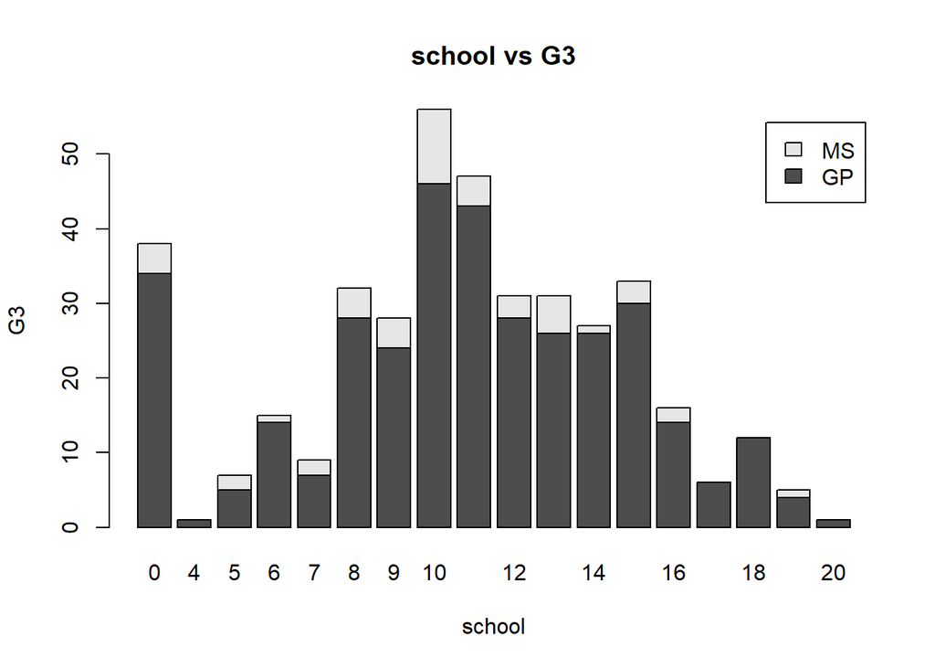

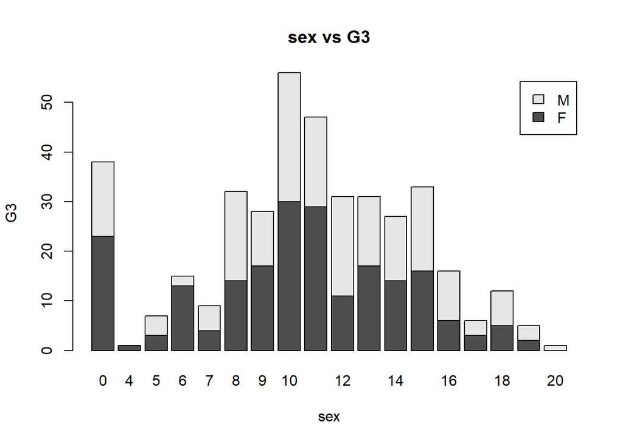

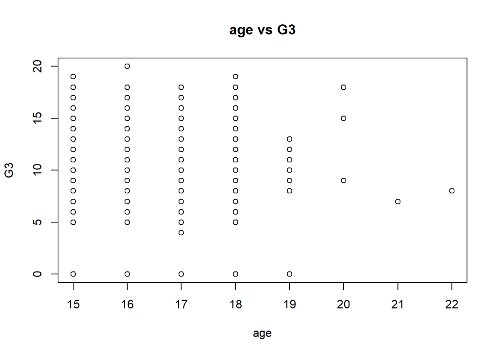

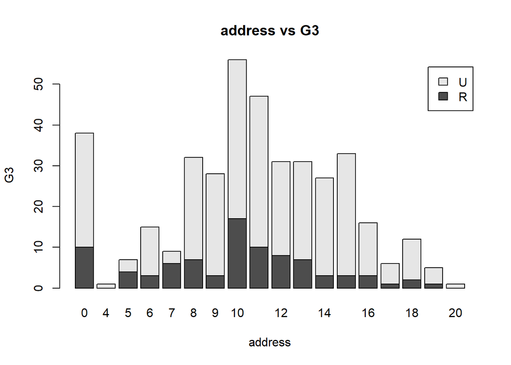

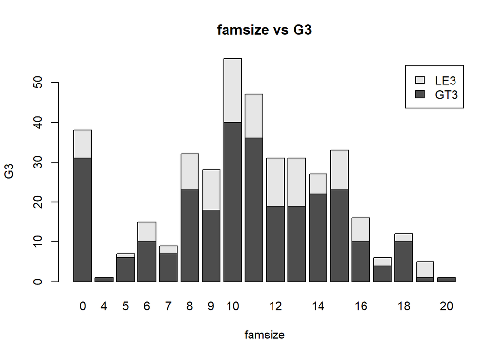

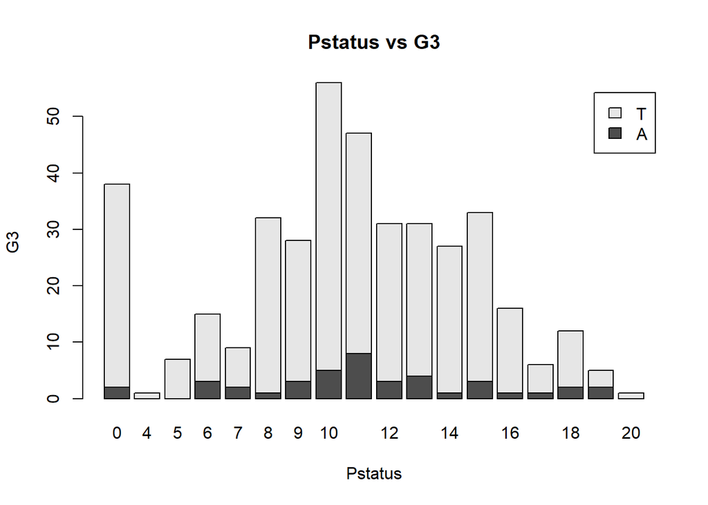

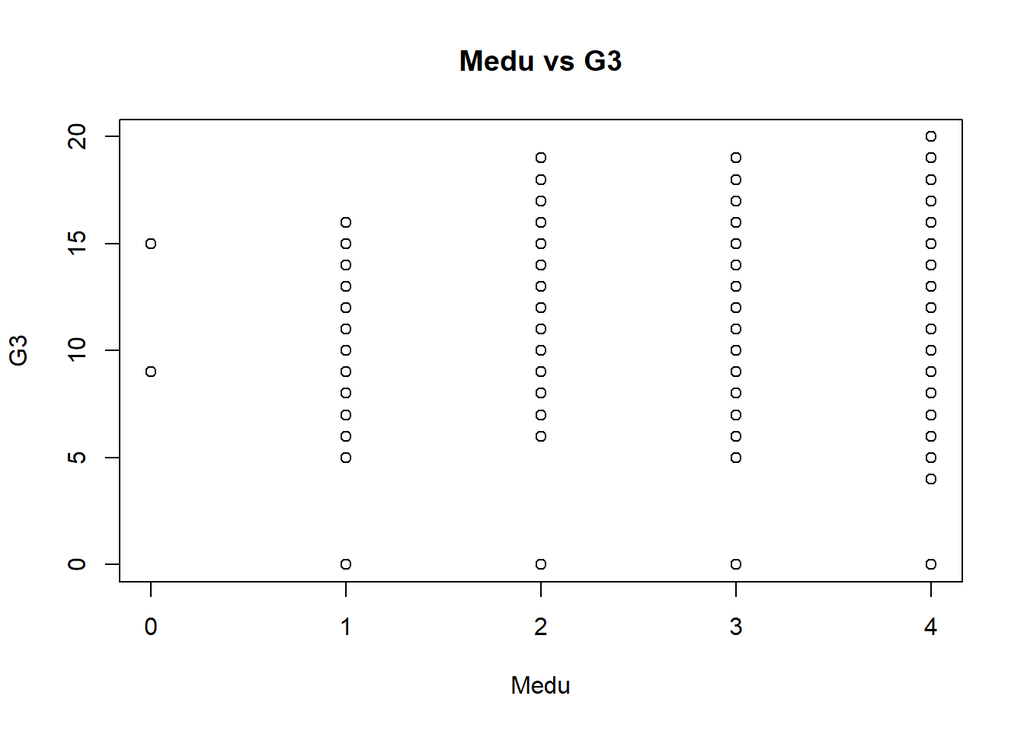

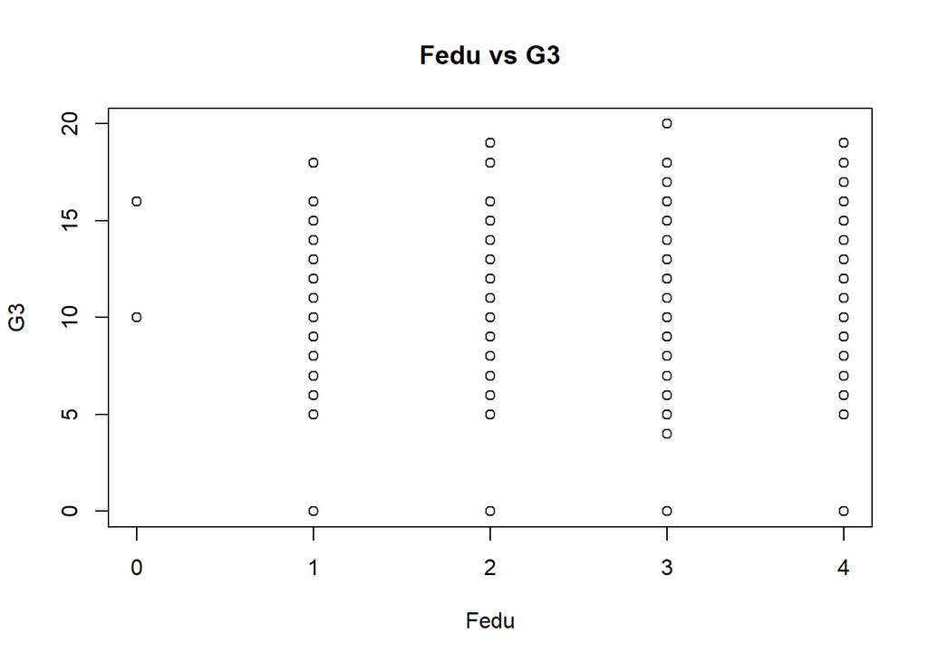

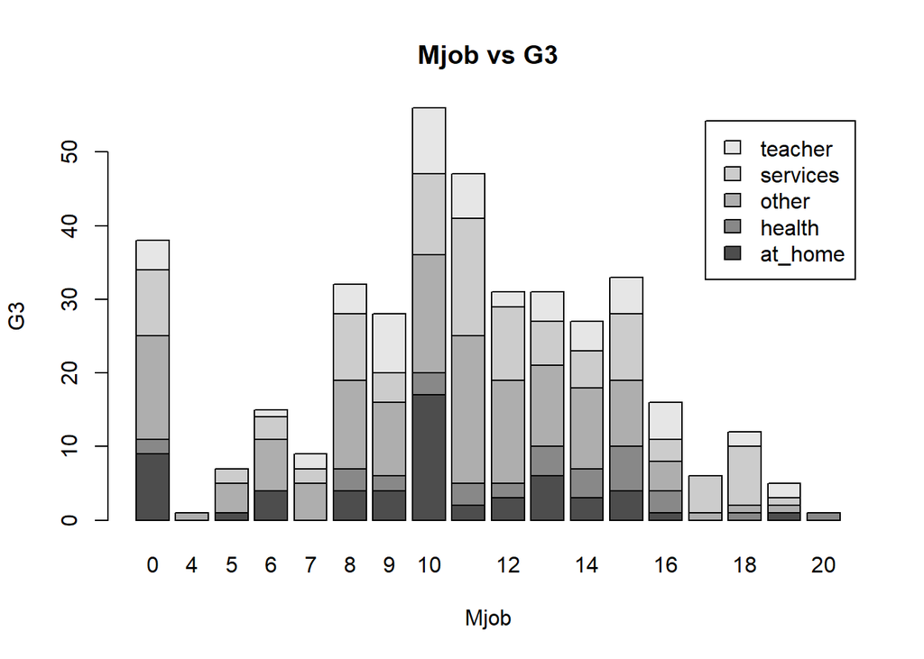

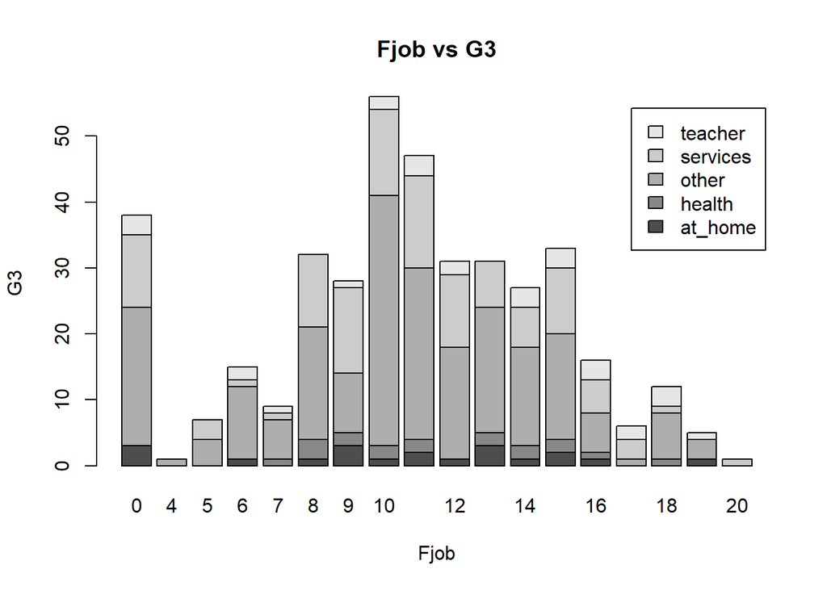

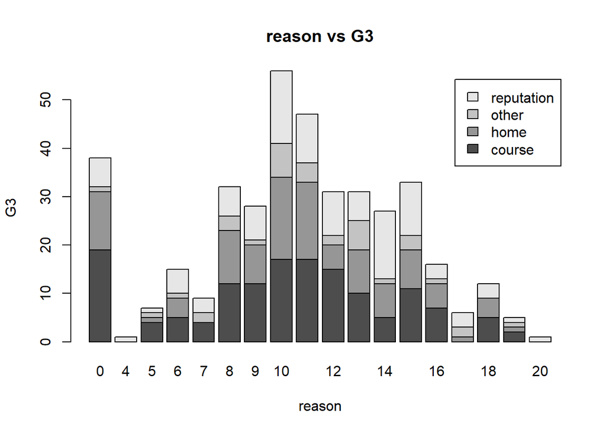

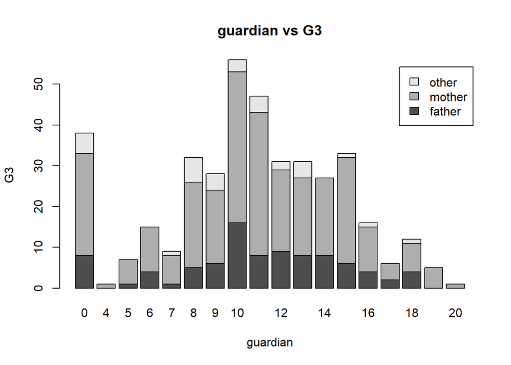

[20 more figures not shown]

```r
# Define a vector of variable types
var_types = sapply(student_data, class)


for (col in names(student_data)[-19]) {

  # if column is numerical, perform correlation test and plot scatter plot
  if (is.numeric(student_data[[col]])) {
    cor.test(student_data[[col]], student_data$G3)
    plot(student_data[[col]], student_data$G3, main = paste(col, "vs G3"), xlab = col, ylab = "G3")
  }

  # if column is categorical, perform chi-squared test and plot stacked bar chart
  else {
    chisq.test(table(student_data[[col]], student_data$G3))
    tab = table(student_data[[col]], student_data$G3)
    barplot(tab, main = paste(col, "vs G3"), xlab = col, ylab = "G3", legend = rownames(tab))
  }

}
```

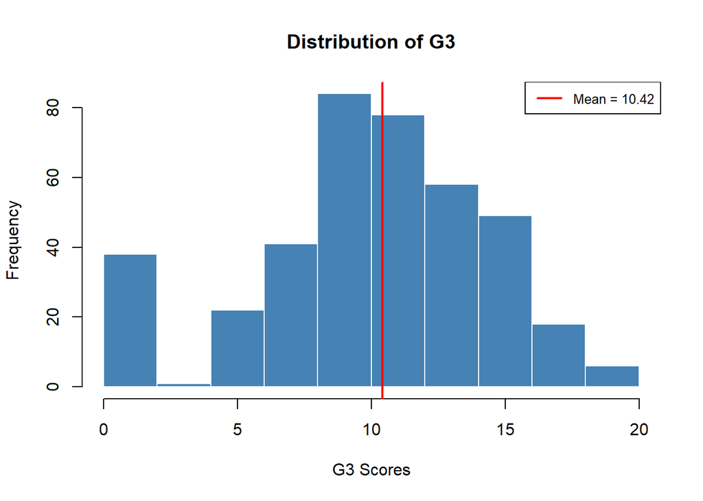

```r
hist(student_data$G3, main = "Distribution of G3", xlab = "G3 Scores", ylab = "Frequency", col = "steelblue", border = "white")


abline(v = mean(student_data$G3), col = "red", lwd = 2)


legend("topright", legend = paste("Mean =", round(mean(student_data$G3), 2)), col = "red", lwd = 2, cex = 0.8)
```

12. (0.5 pt) Split the data into train and test. Use 80% of samples for training and 20% of samples for testing

```r
library(caret)
set.seed(123)


train_in = createDataPartition(student_data$G3, p = 0.8, list = FALSE)
training_set = student_data[train_in, ]
testing_set = student_data[-train_in, ]
```

13. set the random seed: set.seed(123)

```r
set.seed(123)
```

14. (2 pt) Use caret package to run 10 fold cross validation using linear regression method on the train data to predict the “G3” variable . Print the resulting model to see the cross validation RMSE. In addition, take a summary of the model and interpret the coefficients. Which coefficients are statistically different from zero? What does this meant?

```r
library(caret)
set.seed(123)
train_control = trainControl(method = "cv", number = 10, verboseIter = FALSE)
lm_model = train(G3 ~ ., data = training_set, method = "lm", trControl = train_control)

cat("RMSE: ", lm_model$results$RMSE, "\n")
```

```
## RMSE:  2.121982
```

```r
cat("Coefficients:\n")
```

```
## Coefficients:
```

```r
summary(lm_model$finalModel)$coefficients[, c("Estimate", "Std. Error", "t value", "Pr(>|t|)")]
```

```
##                      Estimate Std. Error     t value     Pr(>|t|)
## (Intercept)      -1.682976302 2.43850134 -0.69016829 4.906683e-01
## schoolMS          0.501831868 0.43637395  1.15000418 2.511376e-01
## sexM              0.267777574 0.27130959  0.98698160 3.245161e-01
## age              -0.197226080 0.11349999 -1.73767485 8.338355e-02
## addressU          0.269567525 0.32411821  0.83169508 4.063001e-01
## famsizeLE3        0.116162354 0.26537024  0.43773693 6.619194e-01
## PstatusT         -0.085610982 0.40051296 -0.21375334 8.308972e-01
## Medu              0.153946881 0.18148896  0.84824377 3.970373e-01
## Fedu             -0.144971468 0.15411205 -0.94068871 3.476870e-01
## Mjobhealth        0.339435041 0.62568014  0.54250570 5.879080e-01
## Mjobother         0.291863851 0.39833147  0.73271602 4.643535e-01
## Mjobservices      0.244412509 0.44178970  0.55323270 5.805519e-01
## Mjobteacher      -0.124649915 0.58596663 -0.21272528 8.316983e-01
## Fjobhealth        0.408447871 0.75870393  0.53834949 5.907697e-01
## Fjobother        -0.030348932 0.56882587 -0.05335364 9.574887e-01
## Fjobservices     -0.257039295 0.58837812 -0.43686073 6.625539e-01
## Fjobteacher       0.009784851 0.70620355  0.01385557 9.889552e-01
## reasonhome       -0.288322067 0.30149522 -0.95630727 3.397539e-01
## reasonother       0.149290222 0.43208643  0.34551009 7.299741e-01
## reasonreputation -0.150607342 0.31040316 -0.48519913 6.279200e-01
## guardianmother    0.217840370 0.28885658  0.75414716 4.514038e-01
## guardianother    -0.224790632 0.52231031 -0.43037755 6.672569e-01
## traveltime        0.224011146 0.18338113  1.22156049 2.229162e-01
## studytime        -0.099408718 0.15324933 -0.64867311 5.170890e-01
## failures         -0.009839357 0.19617777 -0.05015531 9.600349e-01
## schoolsupyes      0.376151810 0.37273557  1.00916533 3.137792e-01
## famsupyes         0.272482153 0.26116865  1.04331877 2.977136e-01
## paidyes           0.176531794 0.25769009  0.68505464 4.938844e-01
## activitiesyes    -0.292807917 0.23858720 -1.22725746 2.207716e-01
## nurseryyes       -0.231292022 0.29004207 -0.79744302 4.258793e-01
## higheryes         0.272898886 0.59816710  0.45622517 6.485869e-01
## internetyes       0.005350390 0.32721729  0.01635118 9.869660e-01
## romanticyes      -0.245167808 0.25206723 -0.97262864 3.315895e-01
## famrel            0.393856735 0.13362998  2.94736816 3.478780e-03
## freetime          0.091554740 0.12931666  0.70798877 4.795497e-01
## goout            -0.019152263 0.12196345 -0.15703280 8.753338e-01
## Dalc             -0.264246773 0.17151996 -1.54061817 1.245554e-01
## Walc              0.228970669 0.13116699  1.74564245 8.198587e-02
## health            0.020021410 0.08945573  0.22381361 8.230679e-01
## absences          0.044194668 0.01522296  2.90315856 3.992523e-03
## G1                0.206046596 0.07338189  2.80786707 5.342860e-03
## G2                0.938905366 0.06140998 15.28913354 1.196263e-38
```

15. (1pt) Compute RMSE of the model on the test data. You can call “predict” function and pass to it the model (returned by caret train method) and the test data. Then compute RMSE of the predictions returned by the “predict” method.

```r
lm_predictions = predict(lm_model, newdata = testing_set)

summary(lm_predictions)
```

```
##    Min. 1st Qu.  Median    Mean 3rd Qu.    Max.
##  -1.532   7.655  10.173  10.153  13.600  16.947
```

```r
lm_rmse = sqrt(mean((lm_predictions - testing_set$G3)^2))
cat("RMSE on test data: ", lm_rmse, "\n")
```

```
## RMSE on test data:  1.762835
```

16. (2 pts) Use caret and leap packages to run a 10 fold cross validation using step wise linear regression method with backward selection on the train data. The train method by default uses maximum of 4 predictors and reports the best models with 1..4 predictors. We need to change this parameter to consider all predictors. So inside your train function, add the following parameter tuneGrid = data.frame(nvmax = 1:n), where n is the number of variables you use to predict “G3”. Which model (with how many variables or nvmax ) has the lowest cross validation RMSE? Take the summary of the final model, which variables are selected in the model with the lowest RMSE?

```r
#install.packages("leap")

# library(caret)
# #library(leap)
#
# set.seed(123)
# formula = as.formula("G3 ~ .")
#
# n = ncol(training_set) - 1
# tune_grid = data.frame(nvmax = 1:n)
#
# model = train(formula,
#                data = training_set,
#                method = "leapSeq",
#                tuneGrid = tune_grid,
#                trControl = trainControl(method = "cv", number = 10),
#                na.action = na.omit,
#                preProcess = c("center", "scale"))
#
# model$results

library(caret)
library(leaps)

ctrl = trainControl(method = "cv", number = 10, savePredictions = TRUE)
lm_fit = train(G3 ~., data = training_set, method = "leapBackward", tuneGrid = data.frame(nvmax = ncol(training_set) - 1), trControl = ctrl)

summary(lm_fit$finalModel)
```

```
## Subset selection object
## 41 Variables  (and intercept)
##                  Forced in Forced out
## schoolMS             FALSE      FALSE
## sexM                 FALSE      FALSE
## age                  FALSE      FALSE
## addressU             FALSE      FALSE
## famsizeLE3           FALSE      FALSE
## PstatusT             FALSE      FALSE
## Medu                 FALSE      FALSE
## Fedu                 FALSE      FALSE
## Mjobhealth           FALSE      FALSE
## Mjobother            FALSE      FALSE
## Mjobservices         FALSE      FALSE
## Mjobteacher          FALSE      FALSE
```

[output cut: 229 more lines]

```r
lm_predictions = predict(lm_fit, newdata = testing_set)
lm_rmse = sqrt(mean((lm_predictions - testing_set$G3)^2))
cat("RMSE of stepwise model on test data: ", lm_rmse, "\n")
```

```
## RMSE of stepwise model on test data:  1.774139
```

17. (0.5 pt) Compute the RMSE of the stepwise model on the test data.
18. (1 pt) use “rpart” function to create a regression tree model from the train data. Get the predictions on test data and compute the RMSE.

```r
#install.packages("rpart.plot")
library(rpart.plot)
library(rpart)

rpart_fit = rpart(G3 ~ ., data = training_set)
rpart_fit
```

```
## n= 318
##
## node), split, n, deviance, yval
##       * denotes terminal node
##
##  1) root 318 6794.481000 10.443400
##    2) G2< 10.5 154 2234.838000  6.967532
##      4) absences< 1 49 1011.633000  3.387755
##        8) G2< 6.5 18    0.000000  0.000000 *
##        9) G2>=6.5 31  685.096800  5.354839
##         18) age>=16.5 15  251.733300  2.866667 *
##         19) age< 16.5 16  253.437500  7.687500 *
##      5) absences>=1 105  302.247600  8.638095
##       10) G2< 7.5 26   42.500000  6.500000 *
##       11) G2>=7.5 79  101.772200  9.341772 *
##    3) G2>=10.5 164  951.951200 13.707320
##      6) G2< 13.5 91  107.604400 11.934070 *
##      7) G2>=13.5 73  201.506800 15.917810
##       14) G2< 16.5 54   50.537040 15.092590 *
##       15) G2>=16.5 19    9.684211 18.263160 *
```

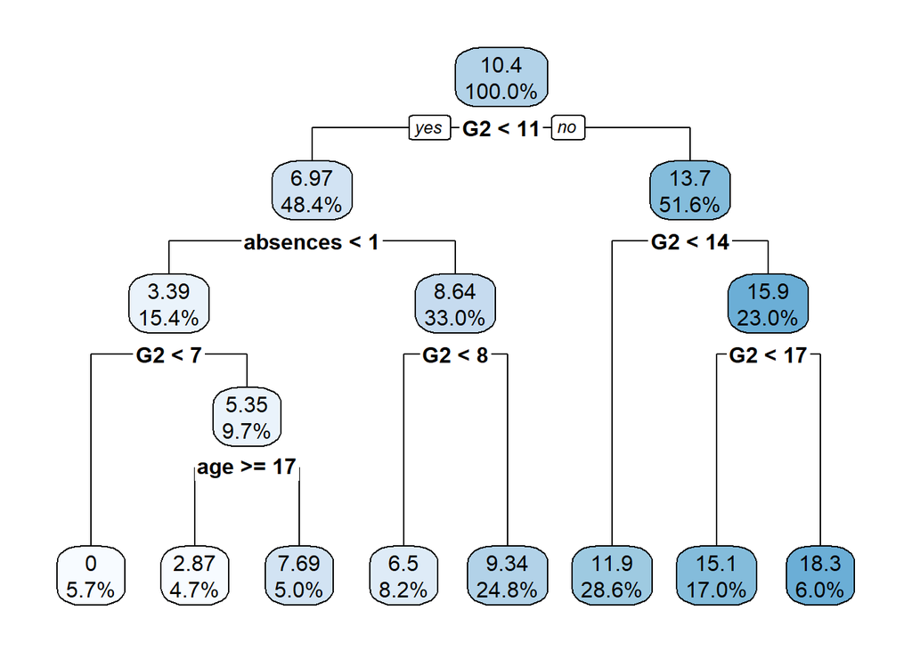

```r
set.seed(123)
library(rpart.plot)
rpart.plot(rpart_fit, digits= 3)
```

```r
rpart_predictions = predict(rpart_fit, newdata = testing_set)
rpart_rmse = sqrt(mean((rpart_predictions - testing_set$G3)^2))
cat("RMSE of regression tree on test data: ", rpart_rmse, "\n")
```

```
## RMSE of regression tree on test data:  1.778623
```

19. (1pt) Compare the RMSE on the test data for linear regression, stepwise regression, and the regression tree.Which model does better at predicting students’ final grade in math?

```r
results = data.frame(model = c("Linear Regression", "Stepwise Regression", "Regression Tree"), RMSE = c(lm_rmse, lm_fit$results$RMSE[which.min(lm_fit$results$RMSE)],rpart_rmse))


print(results)
```

[output not shown]